2018 Edition

# Challenge: What is the future selling price of a home?

A home is often the largest and most expensive purchase a person makes in his or her lifetime. Ensuring homeowners have a trusted way to monitor this asset is incredibly important.

In this competition, students are required to develop a full-fledged approach to make predictions about the future sale prices of homes. A full-fledged approach constist, at least, in the following steps:

- Descriptive statistics about the data
- Data cleaning and pre-processing
- Defining a modeling approach to the problem
- Build such a statistical model
- Validate the outcome of the model

Now, should you ask a home buyer to describe their dream house, they probably wouldn't begin with describing features such as the height of the basement ceiling or the proximity to a railroad. As you will see, the dataset we use in this competition proves that many more features influence price negotiations than the number of bedrooms or a white-picket fence.

With 79 explanatory variables describing (almost) every aspect of residential homes in a small city in the US, this competition challenges you to predict the final price of each home.

# The dataset

## File descriptions

- train.csv - the training dataset
- test.csv - the test dataset
- data_description.txt - full description of each column

## Data fields

Here's a brief version of what you'll find in the data description file.

- SalePrice - the property's sale price in dollars. This is the target variable that you're trying to predict.
- MSSubClass: The building class
- MSZoning: The general zoning classification
- LotFrontage: Linear feet of street connected to property
- LotArea: Lot size in square feet
- Street: Type of road access
- Alley: Type of alley access
- LotShape: General shape of property
- LandContour: Flatness of the property
- Utilities: Type of utilities available
- LotConfig: Lot configuration
- LandSlope: Slope of property
- Neighborhood: Physical locations within Ames city limits
- Condition1: Proximity to main road or railroad
- Condition2: Proximity to main road or railroad (if a second is present)
- BldgType: Type of dwelling
- HouseStyle: Style of dwelling
- OverallQual: Overall material and finish quality
- OverallCond: Overall condition rating
- YearBuilt: Original construction date
- YearRemodAdd: Remodel date
- RoofStyle: Type of roof
- RoofMatl: Roof material
- Exterior1st: Exterior covering on house
- Exterior2nd: Exterior covering on house (if more than one material)
- MasVnrType: Masonry veneer type
- MasVnrArea: Masonry veneer area in square feet
- ExterQual: Exterior material quality
- ExterCond: Present condition of the material on the exterior
- Foundation: Type of foundation
- BsmtQual: Height of the basement
- BsmtCond: General condition of the basement
- BsmtExposure: Walkout or garden level basement walls
- BsmtFinType1: Quality of basement finished area
- BsmtFinSF1: Type 1 finished square feet
- BsmtFinType2: Quality of second finished area (if present)
- BsmtFinSF2: Type 2 finished square feet
- BsmtUnfSF: Unfinished square feet of basement area
- TotalBsmtSF: Total square feet of basement area
- Heating: Type of heating
- HeatingQC: Heating quality and condition
- CentralAir: Central air conditioning
- Electrical: Electrical system
- 1stFlrSF: First Floor square feet
- 2ndFlrSF: Second floor square feet
- LowQualFinSF: Low quality finished square feet (all floors)
- GrLivArea: Above grade (ground) living area square feet
- BsmtFullBath: Basement full bathrooms
- BsmtHalfBath: Basement half bathrooms
- FullBath: Full bathrooms above grade
- HalfBath: Half baths above grade
- Bedroom: Number of bedrooms above basement level
- Kitchen: Number of kitchens
- KitchenQual: Kitchen quality
- TotRmsAbvGrd: Total rooms above grade (does not include bathrooms)
- Functional: Home functionality rating
- Fireplaces: Number of fireplaces
- FireplaceQu: Fireplace quality
- GarageType: Garage location
- GarageYrBlt: Year garage was built
- GarageFinish: Interior finish of the garage
- GarageCars: Size of garage in car capacity
- GarageArea: Size of garage in square feet
- GarageQual: Garage quality
- GarageCond: Garage condition
- PavedDrive: Paved driveway
- WoodDeckSF: Wood deck area in square feet
- OpenPorchSF: Open porch area in square feet
- EnclosedPorch: Enclosed porch area in square feet
- 3SsnPorch: Three season porch area in square feet
- ScreenPorch: Screen porch area in square feet
- PoolArea: Pool area in square feet
- PoolQC: Pool quality
- Fence: Fence quality
- MiscFeature: Miscellaneous feature not covered in other categories
- MiscVal: Value (in dollars) of miscellaneous feature
- MoSold: Month Sold
- YrSold: Year Sold
- SaleType: Type of sale
- SaleCondition: Condition of sale

# Goal of the challenge

It is your job to predict the sales price for each house. For each Id in the test set, you must predict the value of the SalePrice variable.

## Metric

Notebooks are evaluated on Root-Mean-Squared-Error (RMSE) between the logarithm of the predicted value and the logarithm of the observed sales price. (Taking logs means that errors in predicting expensive houses and cheap houses will affect the result equally.)

```python
import numpy as np

def rmse(pred,obs):
    predLog=[np.log(p) for p in pred]
    obsLog=[np.log(o) for o in obs]
    err=0
    for (o,p) in zip(obsLog,predLog):
        err+=(o-p)**2
    return np.sqrt(err/len(pred))

#test
rmse([1,2],[2,4])
```

```
0.6931471805599453
```

## Submission File Format

The file should contain a header and have the following format:

```
Id,SalePrice
1461,169000.1
1462,187724.1233
1463,175221
etc.
```

You will find an example submission file within the data directory in the repository.

# Grading the notebook

This challenge is going to be graded as a regular notebook for the AML labs. As a consequence, students should submit:

- the html version of the notebook, using the Data Science Labs submission website, as usual [**Assignement: Challenge Notebook**]
- the submission file (in csv format), that we will use to rank students according to the metric defined above, again through the Data Science Labs submission website [**Assignement: Challenge Predictions**]

In summary, you will have to submit 2 files!

> Below this line, everything has been written by the group 16 students so the `<div class="alert alert-warning">` has been omitted.

# 1. Descriptive statistics about the data

## 1.1 Categories

Firstly, let's look at the available CSV data.

The data categories don't really match what an average buyer would look for in a house. Firstly because there are 79 categories - no buyer will look for as much informations, and some categories are quite unexpected, like the roof type. We expect that some factors will contribute a lot more to the price of the house than other ones.

Some data types are quantitative (integers for example) and others are categorical (strings), and both of them seem to matter. Our model will thus need to take into account both of them, which is not that straight-forwward.

We notice that some categories are almost empty, like Alley, so we will have to clean the data set.

Some categories take the same value for each house, like the Street, sothey don't seems very useful.

We have already noticed that some categories have linked values, such as BsmtFinSF2 and BsmtUnfSF. It will thus be necessary for our model to take into account the correlation between some inputs.

We take into consideration that two categories are `id` and `salePrice` and are not to be considered as input parameters.

## 1.2 Import and basic cleaning

Now, we want to do some statistic observations. To do so, let's define a few functions to fetch the data and its relevant attibutes.

We'll create the following objects:

| name | type | description |
| --- | --- | --- |
| data | list(dict(string)) | example: data[n]["alley"] represents the `alley` parameter of the n-th house |
| data_quant | list(dict(string)) | same as `data`, but only for the quantitative data |
| data_qual | list(dict(float)) | same as `data`, but only for the categorical data |
| data_forceQual | list(dict(float)) | same as `data`, but all the data has been force-cast to floats, more below |
| data_fq | list(list(float)) | same as above but with a list instead of a dictionnary |
| params | list(string) | all the 79 parameters |
| params_qual | list(string) | only the categorical parameters, as defined by the function isQual(param) |
| params_quant | list(string) | only the quantitative parameters, as defined by the function isQual(param) |
| prices | list(float) | an array with all the 1200 prices |

```python
def import_data(path):
    """
    returns 'data' (see 1.2 statistics), the parameteters detected, and the prices
    """
    f=open(path)
    lines=f.readlines()
    f.close()
    for i in range(len(lines)):
        lines[i]=lines[i].split(",")
        lines[i][-1]=lines[i][-1][0:-1]

    #parameters: [MSSubClass, MSZoning, ..., Sale Condition]
    params=lines[0][1:-1]

    #only the house data
    lines=lines[1:]

    #price
    prices=[l[-1] for l in lines]

    #data
    data=[{} for i in range(len(lines))]
    for dataNumber in range(len(lines)):
        for paramNumber in range(len(params)):
            data[dataNumber][params[paramNumber]]=lines[dataNumber][paramNumber+1]
    return (data,params,prices)

def isQual(data,param):
    """
    returns True if the specified parameter of the data represents a number
    """
    for d in data:
        try:
            float(d[param])
        except ValueError:
            return False
    return True

def selectQual(data,params):
    """
    returns 'data_qual' (see 1.2 statistics) and the categorical parameters
    """
    ret=[]
    qualParams=[]
    for p in params:
        if isQual(data,p):
            qualParams.append(p)
    for d in data:
        ret.append({})
        for qp in qualParams:
            ret[-1][qp]=d[qp]
    return ret,qualParams

def selectQuant(data,params):
    """
    returns 'data_quant' (see 1.2 statistics) and the quantitative parameters
    """
    ret=[]
    quantParams=[]
    for p in params:
        if not isQual(data,p):
            quantParams.append(p)
    for d in data:
        ret.append({})
        for qp in quantParams:
            ret[-1][qp]=d[qp]
    return ret,quantParams
```

```python
data,params,prices = import_data("challenge_data/train.csv")
prices=[float(p) for p in prices]
print("first five parameters:")
for i in range(5):
    print(". ",params[i])
print("first five prices:")
for i in range(5):
    print(". ",prices[i])
print("some data:")
for i in range(3):
    print(". house #"+str(i)+":")
    for j in range(3):
        print(". . "+params[j]+" => "+data[i][params[j]])

data_qual,params_qual=selectQual(data,params)
data_quant,params_quant=selectQuant(data,params)
print("categorical data, house #1:")
for i in range(5):
    print(". "+params_qual[i]+"=>"+data_qual[1][params_qual[i]])
print("quantitative data, house #1:")
for i in range(5):
    print(". "+params_quant[i]+"=>"+data_quant[1][params_quant[i]])
```

```
first five parameters:
.  MSSubClass
.  MSZoning
.  LotFrontage
.  LotArea
.  Street
first five prices:
.  208500.0
.  181500.0
.  223500.0
.  140000.0
.  250000.0
some data:
. house #0:
. . MSSubClass => 60
. . MSZoning => RL
. . LotFrontage => 65
. house #1:
. . MSSubClass => 20
. . MSZoning => RL
. . LotFrontage => 80
. house #2:
. . MSSubClass => 60
. . MSZoning => RL
. . LotFrontage => 68
categorical data, house #1:
. MSSubClass=>20
. LotArea=>9600
. OverallQual=>6
. OverallCond=>8
. YearBuilt=>1976
quantitative data, house #1:
. MSZoning=>RL
. LotFrontage=>80
. Street=>Pave
. Alley=>NA
. LotShape=>Reg
```

Everything seems to work well... but wait, why is house #1's `LotFrontage` a quantitative data?

Diving into `train.csv`, we observe that several entries have their `LotFrontage` parameter set to `NA`, which makes out algorithm view the `LotFrontage` parameter as being quantitative. We thus need the `data_forceQual`, where every datum is cast to a numeric value (label encoding).

Further observation, numbers in the original CSV file are only non-negative integers. We'll thus convert strings into negative integers in order to differentiate them.

```python
import copy
def forceQual(data,params):
    paramsValue={}
    ret=copy.deepcopy(data) # <--- beware of mutable/immutable! ret=data modifies the data!
    for p in params:
        paramsValue[p]=[]
    for i in range(len(ret)):
        for j in range(len(params)):
            p=params[j]
            d=ret[i][p]
            try:
                #datum is cast to a float
                ret[i][p]=float(d)
            except ValueError:
                #datum can't be cast to a float
                try:
                    #identical datum has already been force cast to a negative int
                    val=paramsValue[p].index(d)
                    ret[i][p]=-val-1
                except ValueError:
                    #identical datum has never been force cast to a negative int
                    paramsValue[p].append(d)
                    val=paramsValue[p].index(d)
                    ret[i][p]=-val-1
    return ret
```

```python
data_forceQual=forceQual(data,params)

for i in range(3):
    p=params_quant[i]
    print("quantitative parameter: ",p)
    for j in range(5,10):
        print("house #"+str(j)+":",data[j][p],"=>",data_forceQual[j][p])

data_fq=[]
for d in data_forceQual:
    data_fq.append([])
    for p in d:
        data_fq[-1].append(d[p])
```

```
quantitative parameter:  MSZoning
house #5: RL => -1
house #6: RL => -1
house #7: RL => -1
house #8: RM => -2
house #9: RL => -1
quantitative parameter:  LotFrontage
house #5: 85 => 85.0
house #6: 75 => 75.0
house #7: NA => -1
house #8: 51 => 51.0
house #9: 50 => 50.0
quantitative parameter:  Street
house #5: Pave => -1
house #6: Pave => -1
house #7: Pave => -1
house #8: Pave => -1
house #9: Pave => -1
```

### 1.3 Statistics

Now that the data have been imported and slightly cleaned, let's dive into the stats. Here is the informations that seems relevant for us to find:

- Number of houses
- Amount of quantitative versus categorical
- Parameters: their distribution and their entropy
- Prices: their distribution and their entropy
- Correlation between the parameters
- Qantity of missing values

```python
print("Number of houses",len(data))
print("Amount of quantitative parameters:",len(params_quant))
print("Amount of categorical parameters:",len(params_qual))
```

```
Number of houses 1200
Amount of quantitative parameters: 46
Amount of categorical parameters: 33
```

```python
#Conversion list of prices into arrays
prices_array = np.asarray(prices)

# Minimum price of the data
minimum_price = np.min(prices_array)

# Maximum price of the data
maximum_price = np.max(prices_array)


# Mean price of the data
mean_price = np.mean(prices_array)

# Median price of the data
median_price = np.median(prices_array)


#Standard deviation of prices of the data
std_price = np.std(prices_array)

# There are other statistics you can calculate too like quartiles
first_quartile = np.percentile(prices_array, 25)
third_quartile = np.percentile(prices_array, 75)
inter_quartile = third_quartile - first_quartile

# Show the calculated statistics
print ("Statistics for Boston housing dataset:\n")
print ("Minimum price: ${:,.2f}".format(minimum_price))
print ("Maximum price: ${:,.2f}".format(maximum_price))
print ("Mean price: ${:,.2f}".format(mean_price))
print ("Median price ${:,.2f}".format(median_price))
print ("Standard deviation of prices: ${:,.2f}".format(std_price))
print ("First quartile of prices: ${:,.2f}".format(first_quartile))
print ("Second quartile of prices: ${:,.2f}".format(third_quartile))
print ("Interquartile (IQR) of prices: ${:,.2f}".format(inter_quartile))
```

```
Statistics for Boston housing dataset:

Minimum price: $34,900.00
Maximum price: $755,000.00
Mean price: $181,414.63
Median price $163,700.00
Standard deviation of prices: $81,037.12
First quartile of prices: $129,900.00
Second quartile of prices: $214,000.00
Interquartile (IQR) of prices: $84,100.00
```

```python
import seaborn as sns
import matplotlib.pyplot as plt

params_correlation=np.corrcoef(data_fq,rowvar=False) #rowvar=False because row represents an observation and each column a variable

sns.heatmap(params_correlation,center=0)
plt.plot()
```

[output not shown]

```
[]
```

```
[]
```

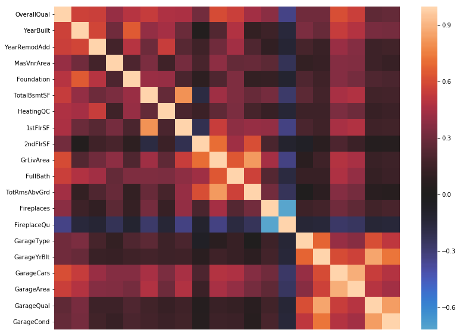

```python
data_cor=copy.deepcopy(data_fq)
params_cor=copy.deepcopy(params)

while (len(data_cor[0])>20):
    cor=np.corrcoef(data_cor,rowvar=False)
    cor=[list(map(lambda x: x*x,y)) for y in cor]
    minsumcor=len(cor)
    minsumcorindex=0
    for i in range(len(cor)):
        sumcor=sum(cor[i])
        if (sumcor)<minsumcor:
            minsumcor=sumcor
            minsumcorindex=i
    for i in range(len(data_cor)):
        data_cor[i]=data_cor[i][0:minsumcorindex]+data_cor[i][minsumcorindex+1:]
    params_cor=params_cor[0:minsumcorindex]+params_cor[minsumcorindex+1:]
cor=np.corrcoef(data_cor,rowvar=False)

plt.figure(figsize=(13,10))
sns.heatmap(cor,center=0,xticklabels=False,yticklabels=params_cor)
plt.plot()
```

A few comments:

1. Most correlations are positive, which indicates that parameters tend to move together, for example an old house (`YearBuilt`) is likely to have an old garage (`GarageYrBlt`).
2. We might be tempted to think that `FireplacesQu` is interesting because it is negatively correlated to other variables, but actually it is not relevant to observe this, because it is a categorical variable. The same way, we can ditch our positive/negative analysis above for all the categorical parameters: `foundation, HeatingQC, GarageType and GarageQual`.
3. The most correlated parameters are the ones poiting to the garage, which explains quite well why these parameters are correlated.

Let's look at it the most correlated factors more precisely using a scatter plot matrix:

```
[]
```

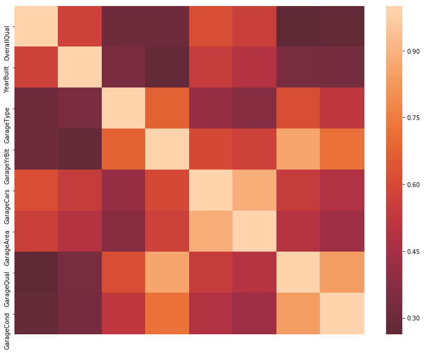

```python
while (len(data_cor[0])>8):
    cor=np.corrcoef(data_cor,rowvar=False)
    cor=[list(map(lambda x: x*x,y)) for y in cor]
    minsumcor=len(cor)
    minsumcorindex=0
    for i in range(len(cor)):
        sumcor=sum(cor[i])
        if (sumcor)<minsumcor:
            minsumcor=sumcor
            minsumcorindex=i
    for i in range(len(data_cor)):
        data_cor[i]=data_cor[i][0:minsumcorindex]+data_cor[i][minsumcorindex+1:]
    params_cor=params_cor[0:minsumcorindex]+params_cor[minsumcorindex+1:]
cor=np.corrcoef(data_cor,rowvar=False)

plt.figure(figsize=(13,10))
sns.heatmap(cor,center=0,xticklabels=False,yticklabels=params_cor)
plt.plot()
```

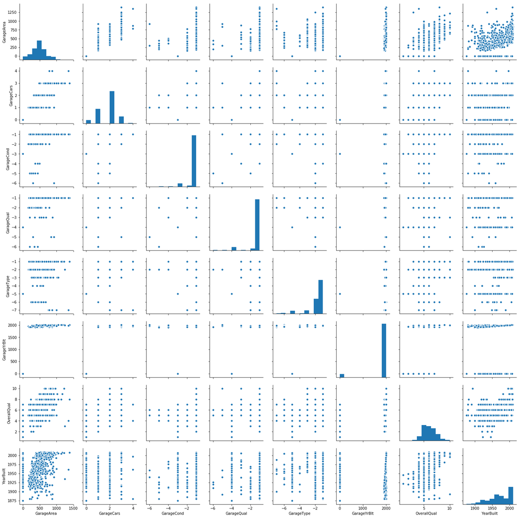

```python
import pandas as pd

data_df={}
for i in range(len(params_cor)):
    p=params_cor[i]
    data_df[p]=[]
    for j in range(len(data_cor)):
        data_df[p].append(data_cor[j][i])

df=pd.DataFrame(data_df)
sns.pairplot(df)
```

This scatter plot matrix (aka pair plot) gives an in-depth detail of the mutual behavior of the most correlated variables. We can observe a few trends:

- `GarageArea - GarageCars`: the bigger the garage, the more we can fit cars inside
- `GarageArea - OverallQuall`: the bigger the garage, the better the overall quality
- `GarageArea - YearBuilt`: if the house is recent, the lower bound for the uncertainty on the size of the garage is high
- `OverallQual - YearBuilt`: it is clear that recent houses are of a better quality and vice versa, but the confidence interval of one parameter given the other is high.

And that's it for the mutual behavior analysis of functions. In a nutshell:

> **Mutual behavior: most parameters are not correlated. The ones who do are positively correlated. The most correlated parameters are the ones we expected, ie they are the one who reflects obvious behavior, eg bigger garage=more cars can be fit into the garage**.

Now let's observe the individual behavior of the parameters, firstly by plotting all of them.

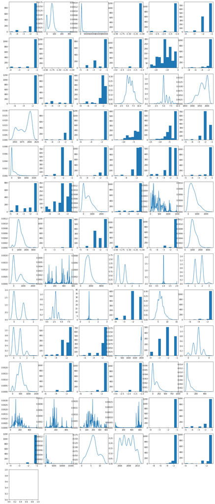

```python
params_vals=np.transpose(data_fq)
params_nb=len(params)
plt.figure(figsize=(20,50))
for i in range(params_nb):
    if params_vals[i].max()<0:
        # categorical
        plt.hist(params_vals[i])
    else:
        #quantitative
        sns.kdeplot(params_vals[i])
    plt.subplot(int(params_nb/6)+1,6,i+1)
plt.show()
```

We can observe that most parameter distribution look different from one another. Besides the fact that some of them are qulitative and some of them are not, among these two categories there is a lot of diversity. Some values are regrouped very close to one another, but some parameters' distribution is quite hectic.

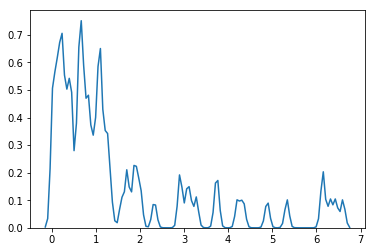

```python
import scipy as sp

proba=[]
for p in params_vals :
    distr={}
    for d in p:
        if d in distr:
            distr[d]+=1/1200
        else:
            distr[d]=1/1200
    proba.append([distr[k] for k in distr])

entropy=[sp.stats.entropy(p) for p in proba]

sns.kdeplot(entropy,bw=0.05)
```

Some parameters have higher entropy than other, which means that they carry more information. In the following we'll reduce the number of parameters, which comes handy when processing big amount of data.

# 2. A simple linear model

Let's start with a very simple model:

```
price = intercept + b0*param0 + ... + b79*param79
```

```python
data_fq_train=data_fq[0:1000]
y_train=[float(p) for p in prices[0:1000]]
data_fq_test=data_fq[1000:1200]
y_test=[float(p) for p in prices[1000:1200]]
```

```
a few predictions:
house #1000: predicted price $44142, actual price $82000, error 46%
house #1001: predicted price $100188, actual price $86000, error -16%
house #1002: predicted price $231211, actual price $232000, error 0%
house #1003: predicted price $36080, actual price $136905, error 73%
house #1004: predicted price $207936, actual price $181000, error -14%
RMSE: 0.2137528368133138
```

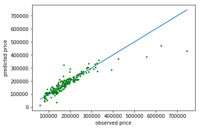

```python
from sklearn.linear_model import LinearRegression
from sklearn.metrics import mean_squared_error,mean_absolute_error

reg=LinearRegression()
reg.fit(data_fq_train,y_train)

linearPredictions=reg.predict(data_fq_test)

plt.ylabel("predicted price")
plt.xlabel("observed price")
plt.plot(y_test,y_test,linewidth=1)
plt.scatter(y_test,linearPredictions,s=5,c='g')

print("a few predictions:")
for i in range(5):
    pred=linearPredictions[i]
    price=y_test[i]
    error=100*(price-pred)/price
    print("house #{}: predicted price ${}, actual price ${}, error {}%".format(1000+i, int(pred), int(price), int(error)))
print("RMSE: {}".format(rmse(y_test,linearPredictions)))
```

We obtain an RMSE of 0.21. Given that the model is quite 'dumb' (label encoding plugged into a linear model, simplicity of the linear model), it gives a good indication of an expected bad RMSE: later on, if we find a smaller RMSE, that's great, but if we find a bigger one, it might indicate an error in our model.

# 3. Neural network

The main observation about the data is its mixed composition - there are both categorical and quantitative data and both are equally important. Untill now, we've used a label encoding for the categorical data but it won't be relevant to plug label-encoded categorical data into a NN. Therefore we'll opt for one-hot encoding.

We'll be left with a lot of variables, which affects the NN's performance. Considerations about entropy shows that some parameters carry almost no information. Therefore, we'll compress data into a reduced set of parameters using PCA.

The compressed data will then be pluggen into a NN whose parameters will be chosen thanks to a bayesian optimization.

## 3.1 Pre-processing

### 3.1.1 Categorical variables processing

Untill now, no particular attention has been focused on the processing of categorical variables - they were just cast to negative integers. Let's do something more relevant to convert every categorical variable into categorical ones.

Categorical parameters can either have an order (eg: bad-good-excellent) or not. Those who have an order are cast to positive integers according to their order. We apply a 1-hot encoding to the other non-orderable parameters.

This also means that orderable parameters are treated 'manually'. We base our order on [this document](https://ww2.amstat.org/publications/jse/v19n3/decock/datadocumentation.txt). This gets reflected onto the `orderable` python variable, which states, for example, that a `LandSlope` parameter of value `Sev` will be cast to a 2.

```python
orderable={
    "LandSlope":["Gtl","Mod","Sev"],
    "Condition1":["Artery","Norm","Feedr","PosN","PosA","RRNn","RRNe","RRAn","RRAe"],
    "Condition2":["Artery","Norm","Feedr","PosN","PosA","RRNn","RRNe","RRAn","RRAe"],
    "HouseStyle":["1Story","1.5Unf","1.5Fin","2Story","2.5Unf","2.5Fin","SFoyer","SLvl"],
    "ExterQual":["Po","Fa","TA","Gd","Ex"],
    "ExterCond":["Po","Fa","TA","Gd","Ex"],
    "BsmtQual":["NA","Po","Fa","TA","Gd","Ex"],
    "BsmtCond":["NA","Po","Fa","TA","Gd","Ex"],
    "BsmtExpose":["NA","No","Mn","Av","Gd"],
    "HeatingQC":["Po","Fa","TA","Gd","Ex"],
    "KitchenQual":["Po","Fa","TA","Gd","Ex"],
    "Functional":["Typ","Min1","Min2","Mod","Maj1","Maj2","Sev","Sal"],
    "FirePlaceQu":["NA","Po","Fa","TA","Gd","Ex"],
    "GarageQual":["NA","Po","Fa","TA","Gd","Ex"],
    "GarageCond":["NA","Po","Fa","TA","Gd","Ex"],
    "PoolQC":["NA","Fa","TA","Gd","Ex"],
    "Fence":["NA","MnWw","GdWo","MnPrv","GdPrv"],
    "SaleType":["Oth","ConLD","ConLI","ConLw","Con","COD","New","VWD","CWD","WD"]
}

data_q=copy.deepcopy(data)
non_orderable={} # non-orderable parameters, with their values
for i in range(len(data_q)):
    for p in data_q[i]:
        if p in orderable:
            # orderable value
            data_q[i][p]=orderable[p].index(data_q[i][p])
        else:
            if data_q[i][p]=="NA":
                data_q[i][p]=0
            try:
                # categorical value
                data_q[i][p]=float(data_q[i][p])
            except ValueError:
                # non-orderable value
                if p not in non_orderable:
                    non_orderable[p]=[]
                if data_q[i][p] not in non_orderable[p]:
                    non_orderable[p].append(data_q[i][p])


import pandas as pd
df=pd.DataFrame(data_q)
dummies=pd.get_dummies(df,prefix=non_orderable.keys())

params=dummies.columns.values
params_vals=np.transpose(dummies.values)

print("Number of parameters:",len(params))
print("A few values:")
for i in [0,3,55,56,57]:
    print("parameter #{}: {}, first values: {}".format(i, params[i], params_vals[i][0:10]))
```

```
Number of parameters: 218
A few values:
parameter #0: 1stFlrSF, first values: [ 856. 1262.  920.  961. 1145.  796. 1694. 1107. 1022. 1077.]
parameter #3: BedroomAbvGr, first values: [3. 3. 3. 3. 4. 1. 3. 3. 2. 2.]
parameter #55: Street_1Fam, first values: [1. 1. 1. 1. 1. 1. 1. 1. 1. 0.]
parameter #56: Street_2fmCon, first values: [0. 0. 0. 0. 0. 0. 0. 0. 0. 1.]
parameter #57: Street_Duplex, first values: [0. 0. 0. 0. 0. 0. 0. 0. 0. 0.]
```

### 3.1.2 Entropy observations

Now let's take a look at the amount of information carried out by the parameters by mapping the entropy in ascending order:

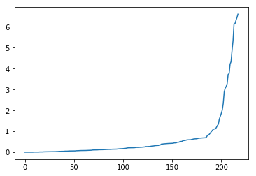

```python
import scipy as sp

proba=[]
for p in params_vals :
    distr={}
    for d in p:
        if d in distr:
            distr[d]+=1/1200
        else:
            distr[d]=1/1200
    proba.append([distr[k] for k in distr])

entropy=[sp.stats.entropy(p) for p in proba]

plt.plot(sorted(entropy))
```

We can observe that some parameters carry way more information than other and that most don't carry a lot of information, which leaves the door open to parameter reduction.

We might be tempted to ditch out the parameters that carry an entropy lower than a certain treshold, but that's not the most relevant technique. Rather, we'll compress the amount of parameters using a PCA analysis.

### 3.1.3 PCA

Principal component analysis (PCA) converts the set of correlated variables into a set of values of uncorrelated varaiables (called principal components). This procedures allows to reduce the number of variables, which is important for the deep learning, and to make the information less redundant.

```
72 variables are enough to explain 0.9869854894228464 of the variance. We'll thus keep this number of parameters.
```

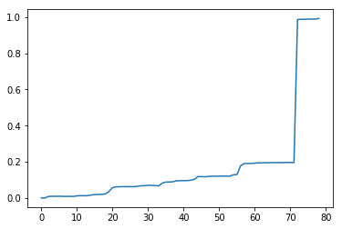

```python
from sklearn.decomposition import PCA
from sklearn.metrics import explained_variance_score
from numpy.linalg import eigh

explainedVariance=0
tresholdPassed=0
explainedVarianceList=[]
for k in range(len(params_vals)):
    pca=PCA(n_components=k)
    pca.fit(params_vals)

    cov=np.cov(params_vals)
    eigenval,eigenvec=eigh(cov)
    u=eigenvec[:k]
    z=np.dot(u,params_vals)
    xappr=np.dot(np.transpose(u),z)

    explainedVariance=explained_variance_score(params_vals,xappr)
    explainedVarianceList+=[explainedVariance]
    if explainedVariance>0.95:
        if tresholdPassed==0:
            tresholdPassed=k

print(tresholdPassed,"variables are enough to explain",explainedVarianceList[tresholdPassed],"of the variance. We'll thus keep this number of parameters.")
plt.plot(explainedVarianceList)
```

```python
pca=PCA(n_components=tresholdPassed)
pca.fit(params_vals)
cov=np.cov(params_vals)

components=pca.components_
x_train=np.transpose(components)[0:1000]
x_test=np.transpose(components)[1000:1200]
```

```python
reg=LinearRegression()
reg.fit(x_train,y_train)

linearPredictions=reg.predict(x_test)
rmse(linearPredictions,y_test)
```

```
0.1843028289366754
```

The RMSE of a linear model gets 3 point below the RMSE obtained with the former data set. This is not a proof that the data set is more relevant, but it is a good indication that it is.

## 3.2 A neural network regression

Let's plug the processed data into a mutli-layer perceptron with the follozing parameters, chosen arbitrarily:

- 3 hidden layers
- 80 hidden units each
- rectified linear activation

```
RMSE: 0.11791130422353603
```

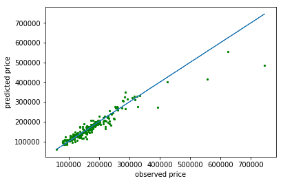

```python
from sklearn.neural_network import MLPRegressor

mlp=MLPRegressor(
    hidden_layer_sizes=[80 for i in range(3)],
    max_iter=200,
    solver="lbfgs"
)
mlp.fit(x_train,y_train)
mlpPredictions=mlp.predict(x_test)

plt.ylabel("predicted price")
plt.xlabel("observed price")
plt.plot(y_test,y_test,linewidth=1)
plt.scatter(y_test,mlpPredictions,s=5,c='g')

print("RMSE: {}".format(rmse(y_test,mlpPredictions)))
```

The prediction seems pretty accurate already compared to what we predicted with former models.

However there are many parameters that we didn't change so there are many vectors of improvement for this network, for example the activation function might not be the best choice. Now let's take a wild guess: more layers and more units mean more intelligence in the network, right? By growing the network bigger, it is likely that the predictions it makes are going to get better - but the computation time is likely to get bigger too.

Let's explore a few MLP configurations to get a glimpse at possible ameliorations:

```
activation: identity, layers: 1x20, computation time: 1s, RMSE: 0.1835781245969156
activation: identity, layers: 1x40, computation time: 2s, RMSE: 0.18383603658380876
activation: identity, layers: 1x80, computation time: 3s, RMSE: 0.18372252013891335
activation: identity, layers: 2x20, computation time: 1s, RMSE: 0.18370317024333305
activation: identity, layers: 2x40, computation time: 3s, RMSE: 0.18449730092070693
activation: identity, layers: 2x80, computation time: 6s, RMSE: 0.1841234070249551
activation: identity, layers: 4x20, computation time: 6s, RMSE: 0.18384417774064177
activation: identity, layers: 4x40, computation time: 9s, RMSE: 0.1847561567810806
activation: identity, layers: 4x80, computation time: 13s, RMSE: 0.18362382331783622
activation: logistic, layers: 1x20, computation time: 0s, RMSE: 0.4062734995227702
activation: logistic, layers: 1x40, computation time: 0s, RMSE: 0.4062734996612899
activation: logistic, layers: 1x80, computation time: 42s, RMSE: 0.22668820897428013
activation: logistic, layers: 2x20, computation time: 0s, RMSE: 0.40627350241413557
activation: logistic, layers: 2x40, computation time: 1s, RMSE: 0.40627388685018045
activation: logistic, layers: 2x80, computation time: 2s, RMSE: 0.4062734944676322
activation: logistic, layers: 4x20, computation time: 1s, RMSE: 0.40627349919414235
activation: logistic, layers: 4x40, computation time: 1s, RMSE: 0.4062734689007515
activation: logistic, layers: 4x80, computation time: 5s, RMSE: 0.40627337859135854
activation: tanh, layers: 1x20, computation time: 0s, RMSE: 0.4062734993573234
activation: tanh, layers: 1x40, computation time: 0s, RMSE: 0.40627349422164244
activation: tanh, layers: 1x80, computation time: 1s, RMSE: 0.4062736404120228
activation: tanh, layers: 2x20, computation time: 0s, RMSE: 0.4062734985934282
activation: tanh, layers: 2x40, computation time: 1s, RMSE: 0.4062735022175787
activation: tanh, layers: 2x80, computation time: 1s, RMSE: 0.4062735018986516
activation: tanh, layers: 4x20, computation time: 1s, RMSE: 0.4062734973382645
activation: tanh, layers: 4x40, computation time: 1s, RMSE: 0.4062734986474209
activation: tanh, layers: 4x80, computation time: 4s, RMSE: 0.4062734719498514
activation: relu, layers: 1x20, computation time: 14s, RMSE: 0.1352477556700782
activation: relu, layers: 1x40, computation time: 20s, RMSE: 0.16387138125347225
activation: relu, layers: 1x80, computation time: 31s, RMSE: 0.14563421507435895
activation: relu, layers: 2x20, computation time: 15s, RMSE: 0.12609947261368112
activation: relu, layers: 2x40, computation time: 28s, RMSE: 0.16215282338415485
activation: relu, layers: 2x80, computation time: 46s, RMSE: 0.14353439692820386
activation: relu, layers: 4x20, computation time: 29s, RMSE: 0.16505041911220145
activation: relu, layers: 4x40, computation time: 45s, RMSE: 0.17610966998979685
activation: relu, layers: 4x80, computation time: 80s, RMSE: 0.10890275481902044
```

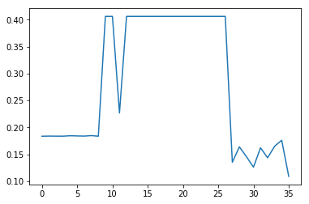

```python
from time import time

activations=['identity', 'logistic', 'tanh', 'relu']
nb_layers=[1,2,4]
nb_units=[20,40,80]
rmseList=[]

for activation in activations:
    for nb_layer in nb_layers:
        for nb_unit in nb_units:
            t=time()
            mlp=MLPRegressor(
                hidden_layer_sizes=[nb_unit for i in range(nb_layer)],
                max_iter=1000,
                solver="lbfgs",
                activation=activation
            )
            mlp.fit(x_train,y_train)
            rmseList.append(rmse(mlp.predict(x_test),y_test))
            print("activation: {}, layers: {}x{}, computation time: {}s, RMSE: {}".format(activation, nb_layer, nb_unit, int(time()-t), rmseList[-1]))

plt.plot(rmseList)
```

First observation, the rectified linear function ('relu', x from 27 to 35) is the most relevant activation function.

However, when observing the MSE of MLPs that used this function, some results seems counterintuitive: the "the bigger the better" assumption concerning the number of layers and units of the MLP is not always verified; results might differ but as we write this a 1x40 MLP performs better than a 4x40 MLP. Therefore we need a more clever way to find the optimal layer configurations of our MLP.

```python
rmseList=[]
for learning_rate in ['constant', 'invscaling', 'adaptive']:
    mlp=MLPRegressor(
        hidden_layer_sizes=[30 for i in range(3)],
        max_iter=200,
        solver="lbfgs",
        activation="relu",
        learning_rate=learning_rate
    )
    mlp.fit(x_train,y_train)
    rmseList.append(rmse(mlp.predict(x_test),y_test))
    print("learning_rate: {}, rmse: {}".format(learning_rate, rmseList[-1]))
```

```
learning_rate: constant, rmse: 0.11500375629902959
learning_rate: invscaling, rmse: 0.1159287273643631
learning_rate: adaptive, rmse: 0.11701149402462116
```

## 3.3 Bayesian optimisation on the neural network

We already found the best activation function, now let's use a bayesian optimisation to find the best neural network shape. To begin with, let's find a 4-layer MLP with an optimized number of hidden inputs.

```
[0.11399583632290106, 0.11725526117735244]
93 0.12650249001663166
```

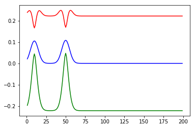

```python
from sklearn.gaussian_process import GaussianProcessRegressor
from sklearn.gaussian_process.kernels import RBF
max_nb_units=200

def rmseNN(nb_units):
    mlp=MLPRegressor(hidden_layer_sizes=[nb_units for i in range(4)],max_iter=1000,solver="lbfgs")
    mlp.fit(x_train,y_train)
    return rmse(y_test,mlp.predict(x_test))

hList=[[10],[50]]
rmseList=[rmseNN(h[0]) for h in hList]
print(rmseList)

while len(hList)<3:

    rmseMin=np.min(rmseList)
    gpr=GaussianProcessRegressor(
        kernel=1*RBF(length_scale=5),
        alpha=1e-3
    )
    gpr.fit(hList,rmseList)
    gprPred,gprStd=gpr.predict([[x] for x in range(1,max_nb_units)],return_std=True)
    gprLow=[p-2*s for (p,s) in zip(gprPred,gprStd)]
    gprHigh=[p+2*s for (p,s) in zip(gprPred,gprStd)]
    expectedImprovement=[(0 if (rmseMin-g<0) else rmseMin-g) for g in gprLow]
    hList.append([np.argmax(expectedImprovement)+1])
    rmseList.append(rmseNN(hList[-1][0]))

    print(hList[-1][0],rmseList[-1])

    plt.plot(range(1,max_nb_units),gprPred,'b')
    plt.plot(range(1,max_nb_units),gprLow,'g')
    plt.plot(range(1,max_nb_units),gprHigh,'r')
```

This is the output of a gaussian process on two values. In blue, the expected RMSE, in green and red, the boundaries of a 95% confidence interval on this prediction.

The expected improvement is the difference between the lowest observed value (0.1139) and the green curve - the highest point on it has in the x-axis the number of hidden units to try next. For computation time purpose we can't go further for now.

# 4 Other models

## 4.1 Ridge regression

```
RMSE: 0.2213133447950573
```

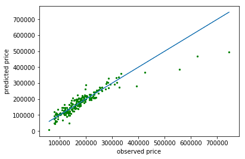

```python
from sklearn.linear_model import Ridge

for a in [1e-5]:
    ridge = Ridge(alpha=a, max_iter=2000)
    ridge.fit(x_train, y_train)
ridgePredictions=ridge.predict(x_test)

plt.ylabel("predicted price")
plt.xlabel("observed price")
plt.plot(y_test,y_test,linewidth=1)
plt.scatter(y_test,ridgePredictions,s=5,c='g')

print("RMSE: {}".format(rmse(y_test,ridgePredictions)))
```

## 4.2 Lasso regression

we assume that the number of variables is lower than the number of individuals. One of the limits of this model is the strong correlations of the variables. If many variables are correlated, then LASSO will select one of them to the detriment of other variables.

```
alpha: 0.5, R^2 score: 0.7933174198927063
alpha: 0.2, R^2 score: 0.792193601359163
alpha: 0.1, R^2 score: 0.791813573811033
alpha: 0.07, R^2 score: 0.7916991648743794
alpha: 0.05, R^2 score: 0.7916225673518485
RMSE: 0.18316858694956678
```

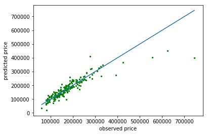

```python
from sklearn.linear_model import Lasso

for a in [5e-1,2e-1,1e-1,7e-2,5e-2]:
    lasso=Lasso(alpha=a,max_iter=4000)
    lasso.fit(x_train,y_train)
    print("alpha: {}, R^2 score: {}".format(a,lasso.score(x_test,y_test)))

lasso=Lasso(alpha=0.07,max_iter=4000)
lasso.fit(x_train,y_train)
lassoPredictions=lasso.predict(x_test)

plt.ylabel("predicted price")
plt.xlabel("observed price")
plt.plot(y_test,y_test,linewidth=1)
plt.scatter(y_test,lassoPredictions,s=5,c='g')

print("RMSE: {}".format(rmse(y_test,lassoPredictions)))
```

### 4.3 Gradient boosting

```
RMSE: 0.16638888777161992
```

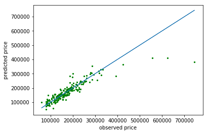

```python
from sklearn.ensemble import GradientBoostingRegressor as GBR

est=GBR(n_estimators=4000,max_depth=1)
est.fit(x_train,y_train)
gbPredictions=est.predict(x_test)

plt.ylabel("predicted price")
plt.xlabel("observed price")
plt.plot(y_test,y_test,linewidth=1)
plt.scatter(y_test,gbPredictions,s=5,c='g')

print("RMSE: {}".format(rmse(y_test,gbPredictions)))
```

### 4.4 XGBoost

```python
!pip install xgboost
```

```
  Using cached https://files.pythonhosted.org/packages/4b/c4/57e246bc99e45c048f9805f2773e7369f0d30896d19fa089fa1794c7b246/xgboost-0.71.tar.gz
  Running setup.py bdist_wheel for xgboost ... done
You are using pip version 9.0.1, however version 10.0.1 is available.
```

```python
import xgboost as xgb
```

```python
model_xgb = xgb.XGBRegressor(colsample_bytree=0.2, gamma=0.0,
                             learning_rate=0.05, max_depth=6,
                             min_child_weight=1.5, n_estimators=7200,
                             reg_alpha=0.9, reg_lambda=0.6,
                             subsample=0.2,seed=42, silent=1,
                             random_state =7)
```

```python
model_xgb.fit(x_train, y_train)
xgb_train_pred = model_xgb.predict(x_test)
```

```
RMSE: 0.18161993736573945
```

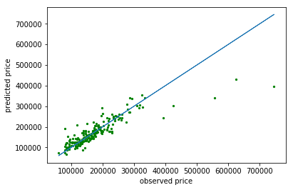

```python
plt.ylabel("predicted price")
plt.xlabel("observed price")
plt.plot(y_test,y_test,linewidth=1)
plt.scatter(y_test,xgb_train_pred,s=5,c='g')

print("RMSE: {}".format(rmse(y_test,xgb_train_pred)))
```

We are supposed to find a RMSE lower than the others.

### 4.5 Light GBM

```python
!pip install lightgbm
```

```
    100% |████████████████████████████████| 716kB 1.1MB/s
You are using pip version 9.0.1, however version 10.0.1 is available.
```

```python
import lightgbm as lgb
```

```python
model_lgb = lgb.LGBMRegressor(objective='regression',num_leaves=5,
                              learning_rate=0.05, n_estimators=720,
                              max_bin = 55, bagging_fraction = 0.8,
                              bagging_freq = 5, feature_fraction = 0.2319,
                              feature_fraction_seed=9, bagging_seed=9,
                              min_data_in_leaf =6, min_sum_hessian_in_leaf = 11)
```

```
RMSE: 0.1542811470698652
```

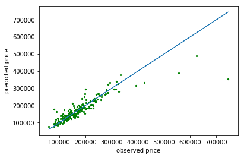

```python
model_lgb.fit(x_train, y_train)
lgb_train_pred = model_lgb.predict(x_test)

plt.ylabel("predicted price")
plt.xlabel("observed price")
plt.plot(y_test,y_test,linewidth=1)
plt.scatter(y_test,lgb_train_pred,s=5,c='g')

print("RMSE: {}".format(rmse(y_test,lgb_train_pred)))
```

### 4.6 Multivariate k-nearest neighbors model

```python
from sklearn.neighbors import KNeighborsRegressor
```

```
RMSE: 0.248506361515097
K = 8
```

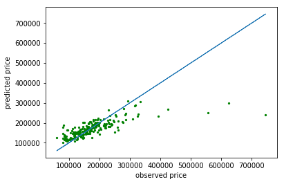

```python
neighPredictions=[0]
neighRMSE=[0]
best_k=0
best_rmse=1
for k in range(1,50):
    neigh = KNeighborsRegressor(n_neighbors=k)
    neigh.fit(x_train, y_train)
    neighPredictions.append(neigh.predict(x_test))
    neighRMSE.append(rmse(y_test,neighPredictions[k]))
    if neighRMSE[k]<best_rmse:
        best_rmse=neighRMSE[k]
        best_k=k



plt.ylabel("predicted price")
plt.xlabel("observed price")
plt.plot(y_test,y_test,linewidth=1)
plt.scatter(y_test,neighPredictions[best_k],s=5,c='g')

print("RMSE: {}".format(rmse(y_test,neighPredictions[best_k])))
print("K =",best_k)
```

### 4.7 Random Forest

```
RMSE: 0.19353068209531418
```

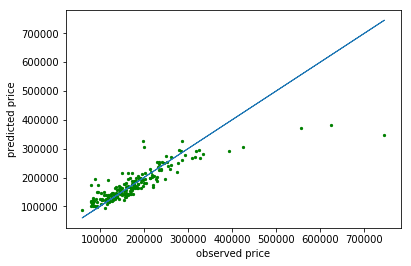

```python
from sklearn.ensemble import RandomForestRegressor

random_forest = RandomForestRegressor(n_estimators=300, random_state=0)
random_forest.fit(x_train, y_train)

random_forest_prediction = random_forest.predict(x_test)

plt.ylabel("predicted price")
plt.xlabel("observed price")
plt.plot(y_test,y_test,linewidth=1)
plt.scatter(y_test,random_forest_prediction,s=5,c='g')

print("RMSE: {}".format(rmse(y_test,random_forest_prediction)))
```

### 4.8 Decision Trees

```
RMSE: 0.29589650964004893
```

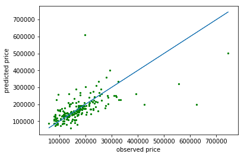

```python
from sklearn.tree import DecisionTreeRegressor

decision_tree = DecisionTreeRegressor()
decision_tree.fit(x_train, y_train)

decision_tree_prediction = decision_tree.predict(x_test)

plt.ylabel("predicted price")
plt.xlabel("observed price")
plt.plot(y_test,y_test,linewidth=1)
plt.scatter(y_test,decision_tree_prediction,s=5,c='g')

print("RMSE: {}".format(rmse(y_test,decision_tree_prediction)))
```

## Conclusion

### Pre-processing and cleaning the data

#### Nominal categories

We proceeded those categories doing the 1-hot encoding.

#### Missing data

To handle the missing values, we noticed a class of “NA” in some categorical parameters. So we converted all the “NA” categorical values in 0 (zero), a quantitative value.

#### PCA to remove the parameters with low variance

We noticed that some parameters were much more important than othes. We also understood that some parameters were strongly correlated. We wanted to remove the categories with very low variance (since they offer little predictive power to models). So we applied the Principal component analysis (PCA), to find an optimal number of parameters to reduce the cost of the next calculations. Since we applied the PCA, at the end we will not be able to find easily the most important features.

### Models

| model | pros | cons | RMSE |
| --- | --- | --- | --- |
| linear model | very simple to implement and interpret | low performance | 0.214 |
| neural network | gives the best results | very complex to find the right parameters | best ones around 0.110 |
| ridge regression | no variable selection, no distribution requirement, does not suffers from multicolinearity | not the best results of all models | 0.221 |
| lasso regression | no distribution requirements | suffers from multicolinearity, variable selection | 0.183 |
| gradient boosting | good performances | easily overfit, long, many hyperparameters that are hard to tweak | 0.166 for SkLearn, 0.154 for LightGBM |
| multivariate k-nearest neighbors | quick, simple to implement, no distribution requirements | bad initialization can cause bad results | 0.249 |
| decision trees | handles outsiders well, easy to interpret, good for few categories variables | easily overfit | 0.296 |
| random forest | same as decision trees, plus fast and scalable | easily overfit | 0.194 |

We could have used cross-validation to estimatethe accuracy of the performance of our predictive models.